# Análise Estatística das Notas do ENEM 2019 no estado de Alagoas

# Classificação das notas em Mesorregiões

```r
meso = read_xlsx('mun_messoregiao.xlsx')
media_mun=aggregate(NOTA_ENEN~NO_MUNICIPIO_RESIDENCIA,data=df,FUN=mean)
media_mun_meso=merge(media_mun,meso,by.x='NO_MUNICIPIO_RESIDENCIA',by.y='mun')
```

| Municípios | Nota | Mesorregião |
| --- | --- | --- |
| Água Branca | 486.0334 | Sertão |
| Anadia | 498.8083 | Leste |
| Arapiraca | 520.3553 | Agreste |
| Atalaia | 480.9068 | Leste |
| Barra de Santo Antônio | 478.8730 | Leste |
| Barra de São Miguel | 500.8136 | Leste |
| Batalha | 488.2814 | Sertão |
| Belém | 476.5333 | Agreste |
| Belo Monte | 474.9516 | Sertão |
| Boca da Mata | 501.7300 | Leste |

## Distribuição das notas por mesorregião

[figure not shown]

```r
nota_cut_m = cut(media_mun_meso$NOTA_ENEN, breaks = quantile(media_mun_meso$NOTA_ENEN),
                 include.lowest = TRUE)

quartis_nota = table(media_mun_meso$mesoregiao, nota_cut_m)

barplot(quartis_nota, beside = TRUE, col = c("lightblue", 5, 'blue'),
        ylab = "Frequência", xlab = "Notas por quartis")

legend(x = "topleft",
       legend = c("Agreste", "Sertão", "Leste"),
       fill = c("lightblue", 5, 'blue'), xpd = TRUE)
```

# Testes de diferença estatística entre as notas das mesorregiões

## Análise de variância entre as médias das mesorregiões

**Para essa análise, inicialmente foi utiilzado o teste da ANOVA**

*H0*: as médias dos grupos são as mesmas

*H1*: pelo menos uma média dos grupos é diferente das demais

```r
res.aov=media_mun_meso%>%
  anova_test(NOTA_ENEN ~ mesoregiao)
```

| Effect | DFn | DFd | F | p | p<.05 | ges |
| --- | --- | --- | --- | --- | --- | --- |
| mesoregiao | 2 | 99 | 1.35 | 0.264 |  | 0.027 |

Como p > 0,05, a hipóstese nula não é rejeitada, ou seja, não existem diferenças significativas entre os grupos (p = 0,264).

**Para analisar as mesorregiões em pares, foi utilizado o pairwise t test**

*H0*: as médias da dupla são as mesmas

*H1*: as médias da dupla são diferentes

```r
pwc <- media_mun_meso %>%
  pairwise_t_test(NOTA_ENEN ~ mesoregiao, p.adjust.method = "bonferroni")
```

| .y. | group1 | group2 | n1 | n2 | p | p.signif | p.adj | p.adj.signif |
| --- | --- | --- | --- | --- | --- | --- | --- | --- |
| NOTA_ENEN | Agreste | Leste | 23 | 53 | 0.441 | ns | 1.000 | ns |
| NOTA_ENEN | Agreste | Sertão | 23 | 26 | 0.108 | ns | 0.324 | ns |
| NOTA_ENEN | Leste | Sertão | 53 | 26 | 0.261 | ns | 0.782 | ns |

Pode-se observar que todos os p.adj foram maiores que 0.05, ou seja, **não há diferença estatística entre as médias das mesorregiões.**

## Gráfico ilustrando a análise de variância

[figure not shown]

```r
pwc <- pwc %>% add_xy_position(x = "mesoregiao")
ggboxplot(media_mun_meso, x = "mesoregiao", y = "NOTA_ENEN",
          xlab = 'Mesorregião') +
  stat_pvalue_manual(pwc, label = "p.adj", tip.length = 0, step.increase = 0.1,) +
  labs(
    subtitle = get_test_label(res.aov, detailed = TRUE),
    caption = get_pwc_label(pwc)
    )
```

# Matriz de correlação entre as notas das 5 disciplinas do ENEM

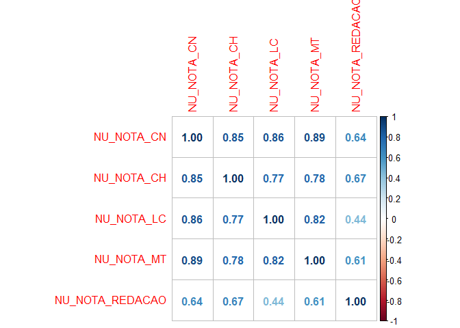

```r
nota_cn = aggregate(NU_NOTA_CN~NO_MUNICIPIO_RESIDENCIA,data=df,FUN=mean)
notas = merge(nota_cn,aggregate(NU_NOTA_CH~NO_MUNICIPIO_RESIDENCIA,data=df,
                                FUN=mean),by='NO_MUNICIPIO_RESIDENCIA')
notas = merge(notas,aggregate(NU_NOTA_LC~NO_MUNICIPIO_RESIDENCIA,data=df,
                              FUN=mean),by='NO_MUNICIPIO_RESIDENCIA')
notas = merge(notas,aggregate(NU_NOTA_MT~NO_MUNICIPIO_RESIDENCIA,data=df,
                              FUN=mean),by='NO_MUNICIPIO_RESIDENCIA')
notas = merge(notas,aggregate(NU_NOTA_REDACAO~NO_MUNICIPIO_RESIDENCIA,data=df,
                              FUN=mean),by='NO_MUNICIPIO_RESIDENCIA')


rownames(notas) = notas$NO_MUNICIPIO_RESIDENCIA
notas$NO_MUNICIPIO_RESIDENCIA = NULL

corrplot(cor(notas), method = 'number')
```

Analisando da matriz de correlação, é possível observar que as disciplinas que apresentaram coeficiente de pearson são as Ciências da Natureza e Matemática.

A partir disso, nós podemos realizar uma regressão linear para identificar a equação de previsão

## Equação de regressão

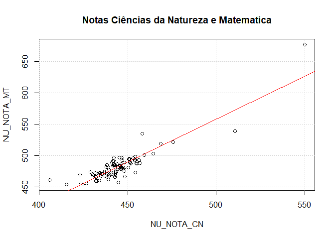

```r
cn_mt=select(notas,NU_NOTA_CN,NU_NOTA_MT)
plot(cn_mt,main='Notas Ciências da Natureza e Matematica')

regressao = lm(cn_mt$NU_NOTA_MT~cn_mt$NU_NOTA_CN)

abline(regressao, col='red')
grid()
```

```r
summary(regressao)
```

```
##
## Call:
## lm(formula = cn_mt$NU_NOTA_MT ~ cn_mt$NU_NOTA_CN)
##
## Residuals:
##     Min      1Q  Median      3Q     Max
## -34.043  -5.736  -0.627   5.277  49.983
##
## Coefficients:
##                    Estimate Std. Error t value Pr(>|t|)
## (Intercept)      -126.21439   30.34340   -4.16 6.75e-05 ***
## cn_mt$NU_NOTA_CN    1.36864    0.06824   20.06  < 2e-16 ***
## ---
## Signif. codes:  0 '***' 0.001 '**' 0.01 '*' 0.05 '.' 0.1 ' ' 1
##
## Residual standard error: 11.1 on 100 degrees of freedom
## Multiple R-squared:  0.8009, Adjusted R-squared:  0.7989
## F-statistic: 402.3 on 1 and 100 DF,  p-value: < 2.2e-16
```

Equação definida como: 1,36*x-126,21

## Teste de hipótese para validar a correlação

*H0*: há normalidade nos dados

*H1*: não há normalidade nos dados.

```r
shapiro.test(regressao$residuals)
```

```
##
##  Shapiro-Wilk normality test
##
## data:  regressao$residuals
## W = 0.91195, p-value = 4.452e-06
```